# N2O ePS + ePSproc preliminary multi-orb analysis: core 1s events (pt 3) MF time-delays

27/10/20

Paul Hockett

*** Preliminary results.

## Background

Basic analysis of N2O ePolyScat results for core ionization events, O(1s) and N(1s). For backgound and methods, see [ePSdata overview](https://phockett.github.io/ePSdata/about.html), [ePSdata methods](https://phockett.github.io/ePSdata/methods.html) and [ePS/ePSproc tutorial docs](https://epsproc.readthedocs.io/en/latest/ePS_ePSproc_tutorial/ePS_tutorial_080520.html).

[Pt 1: analysis of basic photoionization properties and matrix elements.](https://phockett.github.io/ePSdata/N2O-preliminary/N2O_1s_core_preliminary_ePSproc_290920.html)

[Pt 2: angle-resolved observables.](https://phockett.github.io/ePSdata/N2O-preliminary/N2O_1s_core_preliminary_ePSproc_AR_051020_dist.html)

Pt 3: MF time-delays (this doc)

To do list:

- Check electronic structure outputs vs. known thresholds. (From fig. 4 in the PRP it looks like the O(1s) results are shifted up by ~20eV, TBC.)
- Analyse ePS computational precision (via gauge results).
- Estimate accuracy of photoionization properties by comparison with experimental data. (Cf. [recent XeF2 results](https://phockett.github.io/ePSdata/XeF2-preliminary/XeF2_multi-orb_comparisons_270320-dist.html#Comparison-with-expt.) - good, but required ~9eV energy shift, reasons TBC.)
- Finish pt 2.

## Setup

### Env

```python
!hostname
```

```
Stimpy
```

```python
!conda env list
```

```
# conda environments:
#
                         C:\Program Files (x86)\Microsoft Visual Studio\Shared\Anaconda3_64
                         C:\Program Files (x86)\Microsoft Visual Studio\Shared\Anaconda3_64\envs\dataVis3D
                         C:\Program Files (x86)\Microsoft Visual Studio\Shared\Anaconda3_64\envs\dataVis3D-yt
                         C:\Program Files (x86)\Microsoft Visual Studio\Shared\Anaconda3_64\envs\ePSdev
                         C:\Program Files (x86)\Microsoft Visual Studio\Shared\Anaconda3_64\envs\ePSpkgTest2
                         C:\Program Files (x86)\Microsoft Visual Studio\Shared\Anaconda3_64\envs\fibre-sim
                         C:\Program Files (x86)\Microsoft Visual Studio\Shared\Anaconda3_64\envs\ipykernel_py2
                         C:\Program Files (x86)\Microsoft Visual Studio\Shared\Anaconda3_64\envs\pkgTest
                         C:\Program Files (x86)\Microsoft Visual Studio\Shared\Anaconda3_64\envs\pypi-test
                         C:\Program Files (x86)\Microsoft Visual Studio\Shared\Anaconda3_64\envs\seabreeze-bk
                         C:\Program Files (x86)\Microsoft Visual Studio\Shared\Anaconda3_64\envs\test
base                     C:\ProgramData\Anaconda3
ePSdev                   C:\Users\femtolab\.conda\envs\ePSdev
epsInstallTest           C:\Users\femtolab\.conda\envs\epsInstallTest
epsdev                *  C:\Users\femtolab\.conda\envs\epsdev
seabreeze                C:\Users\femtolab\AppData\Local\conda\conda\envs\seabreeze
tensorflow               C:\Users\femtolab\AppData\Local\conda\conda\envs\tensorflow
```

### Load modules

```python
import sys
import os
from pathlib import Path
import numpy as np
# import epsproc as ep
import xarray as xr

from datetime import datetime as dt
timeString = dt.now()
```

```python
# For module testing, include path to module here, otherwise use global installation
if sys.platform == "win32":
    modPath = r'D:\code\github\ePSproc'  # Win test machine
    winFlag = True
else:
    modPath = r'/home/femtolab/github/ePSproc/'  # Linux test machine
    winFlag = False

sys.path.append(modPath)
import epsproc as ep
# # TODO: tidy this up!
# from epsproc.util import matEleSelector
# from epsproc.geomFunc import geomCalc, geomUtils
# from epsproc.geomFunc.lfblmGeom import lfblmXprod

# Plotters
from epsproc.plot import hvPlotters

# Multijob class dev code
from epsproc.classes.multiJob import ePSmultiJob
```

```
* pyevtk not found, VTK export not available.
```

```python
hvPlotters.setPlotters()
# import bokeh
# import holoviews as hv
# hv.extension('bokeh')
```

### Load data

```python
# # Scan for subdirs, based on existing routine in getFiles()
fileBase = r'D:\VMs\Share\ePSshare\N2O\N20_wf'  # Test dir on Stimpy (Win machine)
```

```python
N2Odata = ePSmultiJob(fileBase, verbose = 0)
keys = [0,1,2]  # Set for 1s datasets only (ugly!)
N2Odata.scanFiles(keys = keys)
N2Odata.jobsSummary()
```

```
Found 3 directories, with 21 files.

*** Job orb1 details
Key: orb1
Dir D:\VMs\Share\ePSshare\N2O\N20_wf\orb1_S, 7 files.
{   'batch': 'ePS N2O, batch N2O_wf, orbital orb1_S',
    'event': 'orb 1 ionization (O 1s, S/A1).',
    'orbE': -562.219888836424,
    'orbLabel': 'O 1s, S/A1'}

*** Job orb2 details
Key: orb2
Dir D:\VMs\Share\ePSshare\N2O\N20_wf\orb2_S, 7 files.
{   'batch': 'ePS N2O, batch N2O_wf, orbital orb2_S',
    'event': 'orb 2 ionization (N 1s, S/A1).',
    'orbE': -431.308631832806,
    'orbLabel': 'N 1s, S/A1'}

*** Job orb3 details
Key: orb3
Dir D:\VMs\Share\ePSshare\N2O\N20_wf\orb3_S, 7 files.
{   'batch': 'ePS N2O, batch N2O_wf, orbital orb3_S',
    'event': 'orb 3 ionization (N 1s, S/A1).',
    'orbE': -427.26774100883597,
    'orbLabel': 'N 1s, S/A1'}
```

## System properties

Here orbitals 1,2,3 are all core 1s orbitals, centred on:

1. O
2. N (central)
3. N (terminal)

```
*** Molecular structure
```

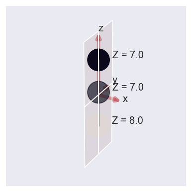

```
*** Molecular orbital list (from ePS output file)
EH = Energy (Hartrees), E = Energy (eV), NOrbGrp, OrbGrp, GrpDegen = degeneracies and corresponding orbital numbering by group in ePS, NormInt = single centre expansion convergence (should be ~1.0).
```

| props orb | Sym | EH | Occ | E | NOrbGrp | OrbGrp | GrpDegen | NormInt |
| --- | --- | --- | --- | --- | --- | --- | --- | --- |
| 1 | S | -20.6612 | 2.0 | -562.219889 | 1.0 | 1.0 | 1.0 | 0.979634 |
| 2 | S | -15.8503 | 2.0 | -431.308632 | 1.0 | 2.0 | 1.0 | 0.999998 |
| 3 | S | -15.7018 | 2.0 | -427.267741 | 1.0 | 3.0 | 1.0 | 0.983661 |
| 4 | S | -1.6338 | 2.0 | -44.457962 | 1.0 | 4.0 | 1.0 | 0.999465 |
| 5 | S | -1.4519 | 2.0 | -39.508211 | 1.0 | 5.0 | 1.0 | 0.999243 |
| 6 | S | -0.8306 | 2.0 | -22.601777 | 1.0 | 6.0 | 1.0 | 0.999545 |
| 7 | P | -0.7759 | 2.0 | -21.113314 | 1.0 | 7.0 | 2.0 | 0.999991 |
| 8 | P | -0.7759 | 2.0 | -21.113314 | 2.0 | 7.0 | 2.0 | 0.999991 |
| 9 | S | -0.6985 | 2.0 | -19.007153 | 1.0 | 8.0 | 1.0 | 0.999692 |
| 10 | P | -0.4961 | 2.0 | -13.499569 | 1.0 | 9.0 | 2.0 | 0.999984 |
| 11 | P | -0.4961 | 2.0 | -13.499569 | 2.0 | 9.0 | 2.0 | 0.999984 |

```
*** Warning: some orbital convergences outside single-center expansion convergence tolerance (0.01):
[[1.         0.97963433]
 [3.         0.98366107]]
```

```python
N2Odata.molSummary()
```

```python
N2Odata.data.keys()
```

```
dict_keys(['orb1', 'orb2', 'orb3'])
```

```python
# Quick manual fix for orb/job labels

N2Odata.jobLabel(key='orb2', lString = " (central)")
N2Odata.jobLabel(key='orb3', lString = " (terminal)")
```

## Molecular frame (MF) results

Making use of the raw matrix elements, the [MFPADs can be computed](https://epsproc.readthedocs.io/en/dev/demos/ePSproc_demo_Aug2019.html#Calculate-MFPADs), as given by:

\begin{equation} I_{\mu_{0}}(\theta_{\hat{k}},\phi_{\hat{k}},\theta_{\hat{n}},\phi_{\hat{n}})=\frac{4\pi^{2}E}{cg_{p_{i}}}\sum_{\mu_{i},\mu_{f}}|T_{\mu_{0}}^{p_{i}\mu_{i},p_{f}\mu_{f}}(\theta_{\hat{k}},\phi_{\hat{k}},\theta_{\hat{n}},\phi_{\hat{n}})|^{2}\label{eq:MFPAD} \end{equation}\begin{equation} T_{\mu_{0}}^{p_{i}\mu_{i},p_{f}\mu_{f}}(\theta_{\hat{k}},\phi_{\hat{k}},\theta_{\hat{n}},\phi_{\hat{n}})=\sum_{l,m,\mu}I_{l,m,\mu}^{p_{i}\mu_{i},p_{f}\mu_{f}}(E)Y_{lm}^{*}(\theta_{\hat{k}},\phi_{\hat{k}})D_{\mu,\mu_{0}}^{1}(R_{\hat{n}})\label{eq:TMF} \end{equation}\begin{equation} I_{l,m,\mu}^{p_{i}\mu_{i},p_{f}\mu_{f}}(E)=\langle\Psi_{i}^{p_{i},\mu_{i}}|\hat{d_{\mu}}|\Psi_{f}^{p_{f},\mu_{f}}\varphi_{klm}^{(-)}\rangle\label{eq:I} \end{equation}

In this formalism:

- $I_{l,m,\mu}^{p_{i}\mu_{i},p_{f}\mu_{f}}(E)$ is the radial part of the dipole matrix element, determined from the initial and final state electronic wavefunctions $\Psi_{i}^{p_{i},\mu_{i}}$and $\Psi_{f}^{p_{f},\mu_{f}}$, photoelectron wavefunction $\varphi_{klm}^{(-)}$ and dipole operator $\hat{d_{\mu}}$. Here the wavefunctions are indexed by irreducible representation (i.e. symmetry) by the labels $p_{i}$ and $p_{f}$, with components $\mu_{i}$ and $\mu_{f}$ respectively; $l,m$ are angular momentum components, $\mu$ is the projection of the polarization into the MF (from a value $\mu_{0}$ in the LF). Each energy and irreducible representation corresponds to a calculation in ePolyScat.
- $T_{\mu_{0}}^{p_{i}\mu_{i},p_{f}\mu_{f}}(\theta_{\hat{k}},\phi_{\hat{k}},\theta_{\hat{n}},\phi_{\hat{n}})$ is the full matrix element (expanded in polar coordinates) in the MF, where $\hat{k}$ denotes the direction of the photoelectron $\mathbf{k}$-vector, and $\hat{n}$ the direction of the polarization vector $\mathbf{n}$ of the ionizing light. Note that the summation over components $\{l,m,\mu\}$ is coherent, and hence phase sensitive.
- $Y_{lm}^{*}(\theta_{\hat{k}},\phi_{\hat{k}})$ is a spherical harmonic.
- $D_{\mu,\mu_{0}}^{1}(R_{\hat{n}})$ is a Wigner rotation matrix element, with a set of Euler angles $R_{\hat{n}}=(\phi_{\hat{n}},\theta_{\hat{n}},\chi_{\hat{n}})$, which rotates/projects the polarization into the MF .
- $I_{\mu_{0}}(\theta_{\hat{k}},\phi_{\hat{k}},\theta_{\hat{n}},\phi_{\hat{n}})$ is the final (observable) MFPAD, for a polarization $\mu_{0}$ and summed over all symmetry components of the initial and final states, $\mu_{i}$ and $\mu_{f}$. Note that this sum can be expressed as an incoherent summation, since these components are (by definition) orthogonal.
- $g_{p_{i}}$ is the degeneracy of the state $p_{i}$.

See: Toffoli, D., Lucchese, R. R., Lebech, M., Houver, J. C., & Dowek, D. (2007). Molecular frame and recoil frame photoelectron angular distributions from dissociative photoionization of NO2. The Journal of Chemical Physics, 126(5), 054307. https://doi.org/10.1063/1.2432124

For some example MFPADs, see [the N2O Pt. 2 notebook](https://phockett.github.io/ePSdata/N2O-preliminary/N2O_1s_core_preliminary_ePSproc_AR_051020_dist.html); here we'll look at the time-delays that arise from this...

The Wigner delay can be given as the energy-derivative of the continuum wavefunction phase, $\arg(\psi_{lm}^{*})$

\begin{equation} \tau_{w}(k,\theta,\phi)=\hbar\frac{d\arg(\psi_{lm}^{*})}{d\epsilon} \end{equation}

And $\psi_{lm}^{*}$ is essentially equivalent to the phase of the $T_{\mu_{0}}^{p_{i}\mu_{i},p_{f}\mu_{f}}(\theta_{\hat{k}},\phi_{\hat{k}},\theta_{\hat{n}},\phi_{\hat{n}})$ functions given above.

For more details see, for example:

- Hockett, Paul, Eugene Frumker, David M Villeneuve, and Paul B Corkum. “Time Delay in Molecular Photoionization.” Journal of Physics B: Atomic, Molecular and Optical Physics 49, no. 9 (May 2016): 095602. https://doi.org/10.1088/0953-4075/49/9/095602.
- Carvalho, C.A.A. de, and H.M. Nussenzveig. “Time Delay.” Physics Reports 364, no. 2 (June 2002): 83–174. https://doi.org/10.1016/S0370-1573(01)00092-8.
- Wigner, Eugene. “Lower Limit for the Energy Derivative of the Scattering Phase Shift.” Physical Review 98, no. 1 (April 1955): 145–47. https://doi.org/10.1103/PhysRev.98.145.

In the current `ePSproc` codes, the [numerical mfpad routine](https://epsproc.readthedocs.io/en/latest/demos/ePSproc_demo_Aug2019.html#Calculate-MFPADs) computes $T_{\mu_{0}}^{p_{i}\mu_{i},p_{f}\mu_{f}}(\theta_{\hat{k}},\phi_{\hat{k}},\theta_{\hat{n}},\phi_{\hat{n}})$. This is now wrapped by a wignerDelay() function, which takes the phase derivatives and converts the units as required.

```python
N2Odata.wignerDelay(selDims = {'Type':'L'})
```

### MF comparison plots

Angle-dependence vs. E plots. By dropping the (sort-of) redundant $\phi$ coord, one can generate $(E,\theta)$ maps which show the main trends. Here each channel is plotted for cross-section, phase and Wigner delay. For the Wigner delays, the threshold region has very large delays, so is plotted separately.

TODO:

- Compare with the known spectroscopy here.
- More detailed analysis.
- Aligned frame theory and analysis to do!

```python
selDims = {'Phi':0, 'Labels':['z','x']}
Erange = [570, 620]  #
ErangeLow = [550, 580]  # Reduced range plot - high Wigner delays in low Eke region
Etype = 'Ehv'
```

#### O(1s)

```
Found dims ('Labels', 'Theta', 'Ehv', 'Sym'), summing to reduce for plot. Pass selDims to avoid.
Grid plot: O 1s, S/A1
Found dims ('Labels', 'Theta', 'Ehv', 'Sym'), summing to reduce for plot. Pass selDims to avoid.
Grid plot: O 1s, S/A1
Found dims ('Labels', 'Theta', 'Ehv', 'Sym'), summing to reduce for plot. Pass selDims to avoid.
Grid plot: O 1s, S/A1
```

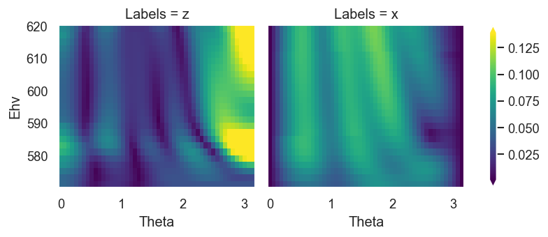

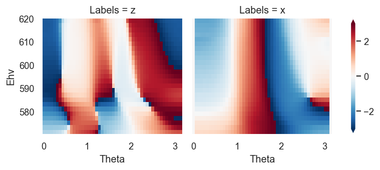

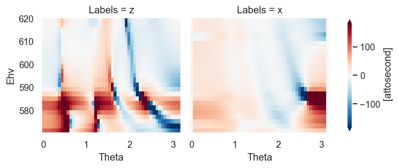

```python
keys = 'orb1'
N2Odata.padPlot(Etype = Etype, Erange = Erange, selDims = selDims, keys = keys, pType = 'a', pStyle='grid', backend = 'mpl')
N2Odata.padPlot(Etype = Etype, Erange = Erange, selDims = selDims, keys = keys, pType = 'phase', pStyle='grid', backend = 'mpl')
N2Odata.padPlot(Etype = Etype, Erange = Erange, selDims = selDims, dataType = 'wigner', keys = keys, pType = 'r', pStyle='grid', backend = 'mpl')
```

```
Found dims ('Labels', 'Theta', 'Ehv', 'Sym'), summing to reduce for plot. Pass selDims to avoid.
Grid plot: O 1s, S/A1
Found dims ('Labels', 'Theta', 'Ehv', 'Sym'), summing to reduce for plot. Pass selDims to avoid.
Grid plot: O 1s, S/A1
```

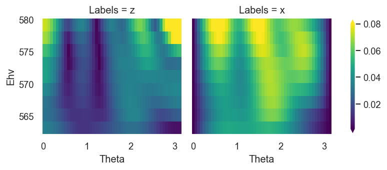

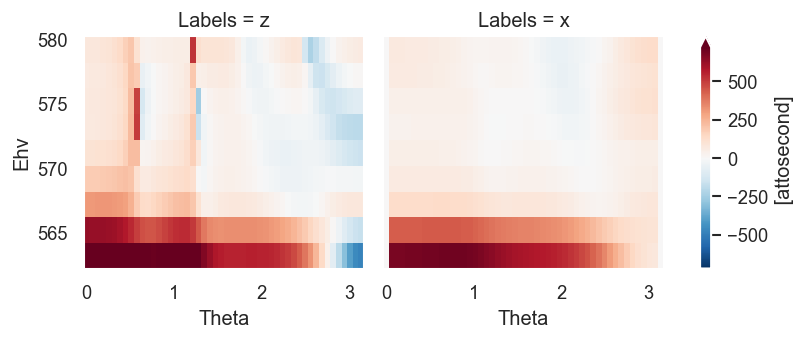

```python
# Low energy region
N2Odata.padPlot(Etype = Etype, Erange = ErangeLow, selDims = selDims, keys = keys, pType = 'a', pStyle='grid', backend = 'mpl')
N2Odata.padPlot(Etype = Etype, Erange = ErangeLow, selDims = selDims, dataType = 'wigner', keys = keys, pType = 'r', pStyle='grid', backend = 'mpl')
```

#### N(1s) central

```
Found dims ('Labels', 'Theta', 'Ehv', 'Sym'), summing to reduce for plot. Pass selDims to avoid.
Grid plot: N 1s, S/A1
Found dims ('Labels', 'Theta', 'Ehv', 'Sym'), summing to reduce for plot. Pass selDims to avoid.
Grid plot: N 1s, S/A1
Found dims ('Labels', 'Theta', 'Ehv', 'Sym'), summing to reduce for plot. Pass selDims to avoid.
Grid plot: N 1s, S/A1
```

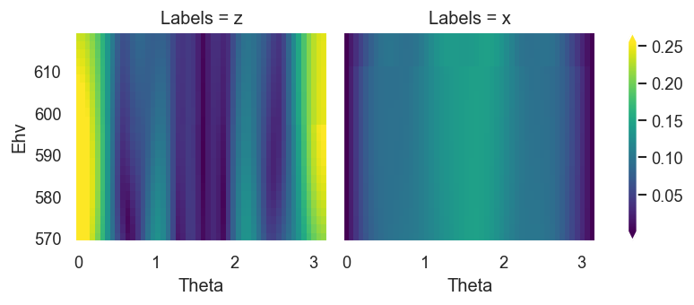

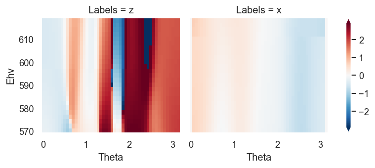

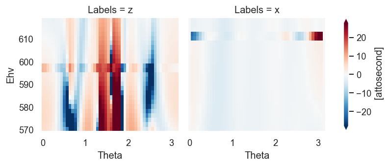

```python
keys = 'orb2'
N2Odata.padPlot(Etype = Etype, Erange = Erange, selDims = selDims, keys = keys, pType = 'a', pStyle='grid', backend = 'mpl')
N2Odata.padPlot(Etype = Etype, Erange = Erange, selDims = selDims, keys = keys, pType = 'phase', pStyle='grid', backend = 'mpl')
N2Odata.padPlot(Etype = Etype, Erange = Erange, selDims = selDims, dataType = 'wigner', keys = keys, pType = 'r', pStyle='grid', backend = 'mpl')
```

```
Found dims ('Labels', 'Theta', 'Ehv', 'Sym'), summing to reduce for plot. Pass selDims to avoid.
Grid plot: N 1s, S/A1
Found dims ('Labels', 'Theta', 'Ehv', 'Sym'), summing to reduce for plot. Pass selDims to avoid.
Grid plot: N 1s, S/A1
Found dims ('Labels', 'Theta', 'Ehv', 'Sym'), summing to reduce for plot. Pass selDims to avoid.
Grid plot: N 1s, S/A1
```

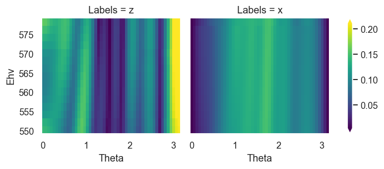

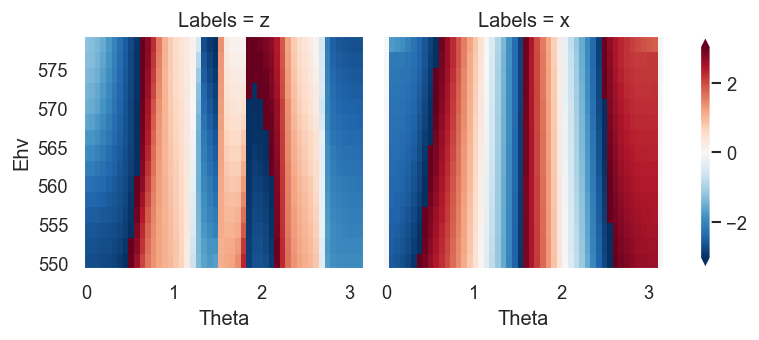

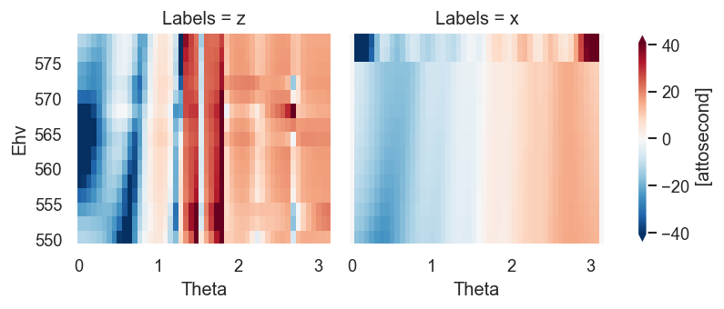

```python
# Low energy region
N2Odata.padPlot(Etype = Etype, Erange = ErangeLow, selDims = selDims, keys = keys, pType = 'a', pStyle='grid', backend = 'mpl')
N2Odata.padPlot(Etype = Etype, Erange = ErangeLow, selDims = selDims, keys = keys, pType = 'phase', pStyle='grid', backend = 'mpl')
N2Odata.padPlot(Etype = Etype, Erange = ErangeLow, selDims = selDims, dataType = 'wigner', keys = keys, pType = 'r', pStyle='grid', backend = 'mpl')
```

#### N(1s) terminal

```
Found dims ('Labels', 'Theta', 'Ehv', 'Sym'), summing to reduce for plot. Pass selDims to avoid.
Grid plot: N 1s, S/A1
Found dims ('Labels', 'Theta', 'Ehv', 'Sym'), summing to reduce for plot. Pass selDims to avoid.
Grid plot: N 1s, S/A1
Found dims ('Labels', 'Theta', 'Ehv', 'Sym'), summing to reduce for plot. Pass selDims to avoid.
Grid plot: N 1s, S/A1
```

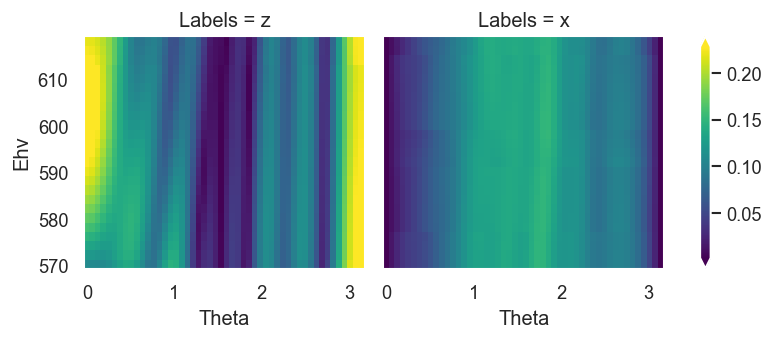

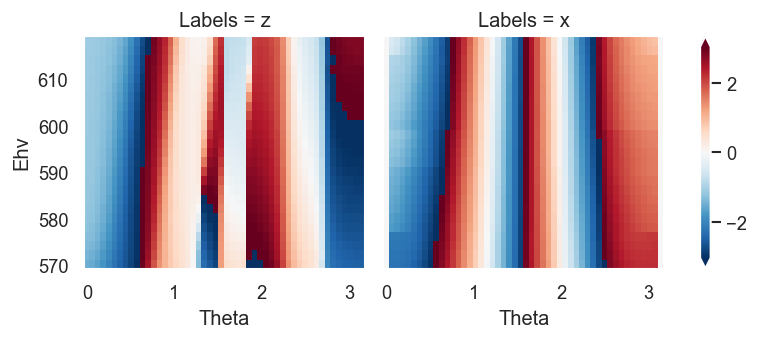

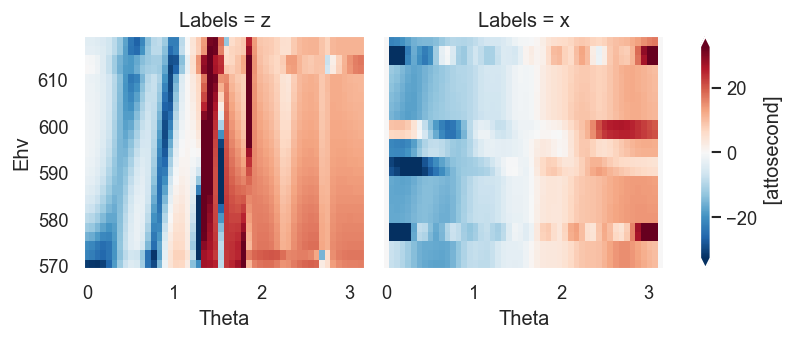

```python
keys = 'orb3'
N2Odata.padPlot(Etype = Etype, Erange = Erange, selDims = selDims, keys = keys, pType = 'a', pStyle='grid', backend = 'mpl')
N2Odata.padPlot(Etype = Etype, Erange = Erange, selDims = selDims, keys = keys, pType = 'phase', pStyle='grid', backend = 'mpl')
N2Odata.padPlot(Etype = Etype, Erange = Erange, selDims = selDims, dataType = 'wigner', keys = keys, pType = 'r', pStyle='grid', backend = 'mpl')
```

The stripes here are likely spurious and due to numerical issues - TBC.

```
Found dims ('Labels', 'Theta', 'Ehv', 'Sym'), summing to reduce for plot. Pass selDims to avoid.
Grid plot: N 1s, S/A1
Found dims ('Labels', 'Theta', 'Ehv', 'Sym'), summing to reduce for plot. Pass selDims to avoid.
Grid plot: N 1s, S/A1
Found dims ('Labels', 'Theta', 'Ehv', 'Sym'), summing to reduce for plot. Pass selDims to avoid.
Grid plot: N 1s, S/A1
```

[figure not shown]

[figure not shown]

[figure not shown]

```python
# Low energy region
N2Odata.padPlot(Etype = Etype, Erange = ErangeLow, selDims = selDims, keys = keys, pType = 'a', pStyle='grid', backend = 'mpl')
N2Odata.padPlot(Etype = Etype, Erange = ErangeLow, selDims = selDims, keys = keys, pType = 'phase', pStyle='grid', backend = 'mpl')
N2Odata.padPlot(Etype = Etype, Erange = ErangeLow, selDims = selDims, dataType = 'wigner', keys = keys, pType = 'r', pStyle='grid', backend = 'mpl')
```

## Versions

```python
import scooby
scooby.Report(additional=['epsproc', 'xarray', 'jupyter'])
```

| Wed Oct 28 14:46:41 2020 Eastern Daylight Time |  |  |  |  |  |
| --- | --- | --- | --- | --- | --- |
| OS | Windows | CPU(s) | 32 | Machine | AMD64 |
| Architecture | 64bit | RAM | 63.9 GB | Environment | Jupyter |
| Python 3.7.3 (default, Apr 24 2019, 15:29:51) [MSC v.1915 64 bit (AMD64)] |  |  |  |  |  |
| epsproc | 1.3.0-dev | xarray | 0.15.0 | jupyter | Version unknown |
| numpy | 1.19.2 | scipy | 1.3.0 | IPython | 7.12.0 |
| matplotlib | 3.3.1 | scooby | 0.5.6 |  |  |
| Intel(R) Math Kernel Library Version 2020.0.0 Product Build 20191125 for Intel(R) 64 architecture applications |  |  |  |  |  |